# Project Business Statistics: E-news Express

**Marks: 60**

# Define Problem Statement and Objectives

E-News Express aims to expand business by acquiring new subscribers. The company plans to study user interest to better drive engagement. The design team has developed a new landing page. To test the effectiveness an experiment was conducted by randomly selecting 100 users and dividing them equally into two groups. Group one (control) was served the existing page while group two (treatment) was served the new page. Data from these groups have been collected to determine the effectiveness of the new page at a significance level of 5%. The following questions are to be answered:

Do the users spend more time on the new landing page than on the existing landing page?

Is the conversion rate (the proportion of users who visit the landing page and get converted) for the new page greater than the conversion rate for the old page?

Does the converted status depend on the preferred language?

Is the time spent on the new page the same for the different language users?

Data Dictionary:

user_id - Unique user ID of the person visiting the website

group - Whether the user belongs to the first group (control) or the second group (treatment)

landing_page - Whether the landing page is new or old

time_spent_on_the_page - Time (in minutes) spent by the user on the landing page

converted - Whether the user gets converted to a subscriber of the news portal or not

language_preferred - Language chosen by the user to view the landing page

# Import all the necessary libraries

```python
#import the packages
import pandas as pd
import numpy as np
import matplotlib.pyplot as plt
import seaborn as sns
%matplotlib inline

import scipy.stats as stats
```

# Reading the Data into a DataFrame

```python
from google.colab import drive
drive.mount('/content/drive')
```

```python
data = pd.read_csv('/content/drive/MyDrive/abtest.csv')
df= data.copy()
```

# Explore the dataset and extract insights using Exploratory Data Analysis

- Data Overview
  - Viewing the first and last few rows of the dataset
  - Checking the shape of the dataset
  - Getting the statistical summary for the variables
- Check for missing values
- Check for duplicates

```python
#Viewing first five rows
df.head()
```

|  | user_id | group | landing_page | time_spent_on_the_page | converted | language_preferred |
| --- | --- | --- | --- | --- | --- | --- |
| 0 | 546592 | control | old | 3.48 | no | Spanish |
| 1 | 546468 | treatment | new | 7.13 | yes | English |
| 2 | 546462 | treatment | new | 4.40 | no | Spanish |
| 3 | 546567 | control | old | 3.02 | no | French |
| 4 | 546459 | treatment | new | 4.75 | yes | Spanish |

```python
#Viewing last five rows
df.tail()
```

|  | user_id | group | landing_page | time_spent_on_the_page | converted | language_preferred |
| --- | --- | --- | --- | --- | --- | --- |
| 95 | 546446 | treatment | new | 5.15 | no | Spanish |
| 96 | 546544 | control | old | 6.52 | yes | English |
| 97 | 546472 | treatment | new | 7.07 | yes | Spanish |
| 98 | 546481 | treatment | new | 6.20 | yes | Spanish |
| 99 | 546483 | treatment | new | 5.86 | yes | English |

```python
#Getting the shape of the data
df.shape
```

```
(100, 6)
```

```python
#Getting a summary of the data with data types
df.info()
```

```
<class 'pandas.core.frame.DataFrame'>
RangeIndex: 100 entries, 0 to 99
Data columns (total 6 columns):
 #   Column                  Non-Null Count  Dtype
---  ------                  --------------  -----
 0   user_id                 100 non-null    int64
 1   group                   100 non-null    object
 2   landing_page            100 non-null    object
 3   time_spent_on_the_page  100 non-null    float64
 4   converted               100 non-null    object
 5   language_preferred      100 non-null    object
dtypes: float64(1), int64(1), object(4)
memory usage: 4.8+ KB
```

```python
#Checking statistical summary of dataset
df.describe()
```

|  | user_id | time_spent_on_the_page |
| --- | --- | --- |
| count | 100.000000 | 100.000000 |
| mean | 546517.000000 | 5.377800 |
| std | 52.295779 | 2.378166 |
| min | 546443.000000 | 0.190000 |
| 25% | 546467.750000 | 3.880000 |
| 50% | 546492.500000 | 5.415000 |
| 75% | 546567.250000 | 7.022500 |
| max | 546592.000000 | 10.710000 |

```python
#Checking for missing values
df.isna().sum()
```

```
user_id                   0
group                     0
landing_page              0
time_spent_on_the_page    0
converted                 0
language_preferred        0
dtype: int64
```

```python
#Checking for duplicates
df.duplicated().sum()
```

```
0
```

Data Overview

There are 100 rows and 6 columns (user_id, group, landing_page, time_spent_on_the_page, converted, and language_preferred)

There are no missing values or duplicates

# Univariate Analysis

## user_id

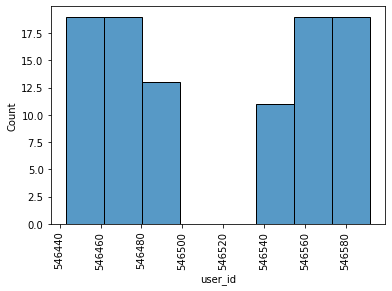

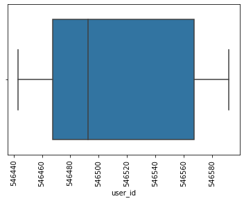

```python
sns.histplot(data= df, x= 'user_id')
plt.xticks(rotation= 90)
plt.show()

sns.boxplot(data= df, x= 'user_id')
plt.xticks(rotation= 90)
plt.show()
```

Insights:

Logically we can see that the user id is a six digit code representing users. Therefore, nothing of significance can be taken from this column alone.

## group

```python
df['group'].value_counts()
```

```
control      50
treatment    50
Name: group, dtype: int64
```

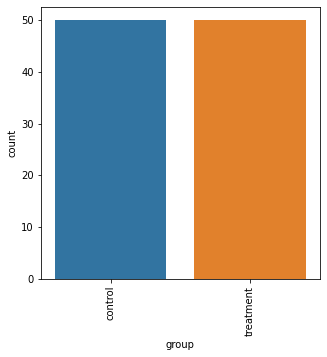

```python
plt.figure(figsize= (5,5))
sns.countplot(data= df, x= 'group');
plt.xticks(rotation= 90)
plt.show()
```

Insights:

The group is evenly split among the 100 rows between control and treatment.

## landing_page

```python
df['landing_page'].value_counts()
```

```
old    50
new    50
Name: landing_page, dtype: int64
```

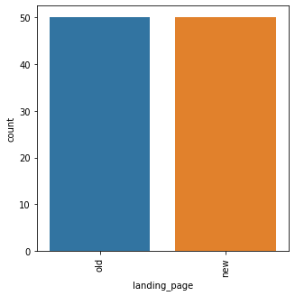

```python
plt.figure(figsize= (5,5))
sns.countplot(data= df, x= 'landing_page');
plt.xticks(rotation= 90)
plt.show()
```

Insights:

The group is evenly split between the 100 rows between old and new (landing_page).

## time_spent_on_the_page

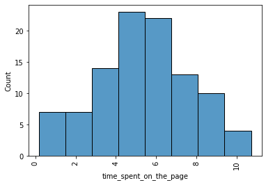

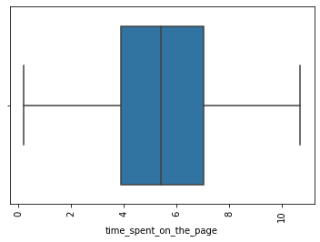

```python
sns.histplot(data= df, x= 'time_spent_on_the_page')
plt.xticks(rotation= 90)
plt.show()

sns.boxplot(data= df, x= 'time_spent_on_the_page')
plt.xticks(rotation= 90)
plt.show()
```

Insights:

The time spent (in Minutes) follows a normal distribution with no visible outliers. The average time spent on the page is around 5.4 minutes with a standard deviation of approximately 2.4 minutes.

## converted

```python
df['converted'].value_counts()
```

```
yes    54
no     46
Name: converted, dtype: int64
```

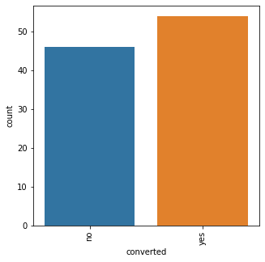

```python
plt.figure(figsize= (5,5))
sns.countplot(data= df, x= 'converted');
plt.xticks(rotation= 90)
plt.show()
```

Insights:

Yes or no corresponds to whether the user was converted to subscribe to the news portal. 54 users were converted while 46 were not.

## language preferred

```python
df['language_preferred'].value_counts()
```

```
Spanish    34
French     34
English    32
Name: language_preferred, dtype: int64
```

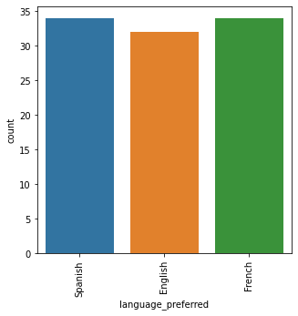

```python
plt.figure(figsize= (5,5))
sns.countplot(data= df, x= 'language_preferred');
plt.xticks(rotation= 90)
plt.show()
```

Insights:

There are three language preferences for the user to choose (Spanish, English and French). The three are closely distributed among the sample population.

# Bivariate Analysis

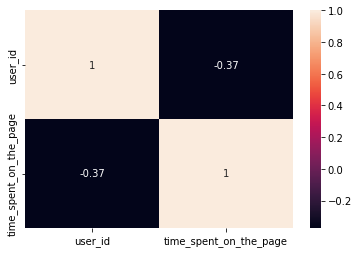

```python
#Using a heatmap to see if there may be any correlations
sns.heatmap(df.corr(),annot=True);
```

## group

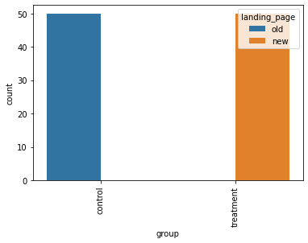

```python
sns.countplot(data= df, x= 'group', hue= 'landing_page');
plt.xticks(rotation= 90);
```

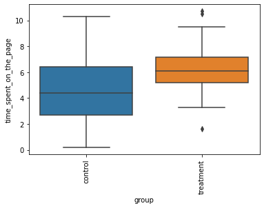

```python
sns.boxplot(data= df, x= 'group', y='time_spent_on_the_page');
plt.xticks(rotation= 90);
```

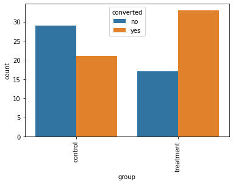

```python
sns.countplot(data= df, x= 'group', hue= 'converted');
plt.xticks(rotation= 90);
```

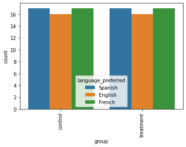

```python
sns.countplot(data= df, x= 'group', hue= 'language_preferred');
plt.xticks(rotation= 90);
```

Insights:

Group and landing page are slightly redundant as the control group will be shown the existing page and the treatment group will be shown the new page, resulting in a 50/50 split from the 100 rows.

Group and time show some significance, as the control group shows a wide distribution of time spent from approximately 0-10 minutes. The treatment group has less variability (from around 3-10 minutes) with some outliers. The average of the treatment group is about 6 minutes compared the the control groups 4 minutes.

There seems to be a distinct difference between conversion between groups, with a higher rate of conversion with the treatment group.

There seems to be an even distribution between preferred language within the groups.

## landing_page

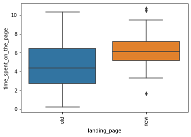

```python
sns.boxplot(data= df, x= 'landing_page', y='time_spent_on_the_page');
plt.xticks(rotation= 90);
```

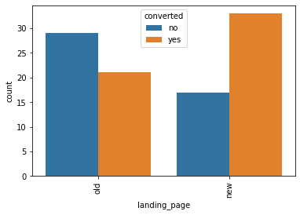

```python
sns.countplot(data= df, x= 'landing_page', hue= 'converted');
plt.xticks(rotation= 90);
```

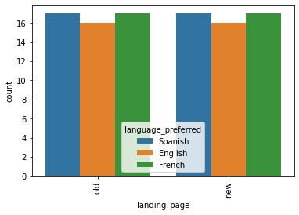

```python
sns.countplot(data= df, x= 'landing_page', hue= 'language_preferred');
plt.xticks(rotation= 90);
```

Insights:

As we have stated before, group and landing page are basically the same. That being said the comparisons between time, converted and language are the same per group. Therefore no new correlations can be found.

## time_spent_on_the_page

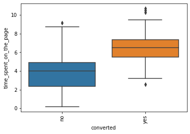

```python
sns.boxplot(data= df, x= 'converted', y='time_spent_on_the_page');
plt.xticks(rotation= 90);
```

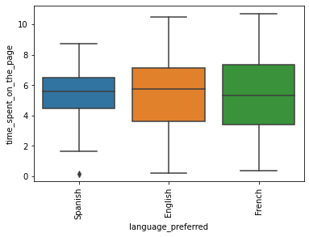

```python
sns.boxplot(data= df, x= 'language_preferred', y='time_spent_on_the_page');
plt.xticks(rotation= 90);
```

Insights:

Time spent and conversion show some significance in correlation. Converted users have a higher average of time spent on the landing page. This would make sense, as more engagement would logically tend to equal a higher conversion rate.

The time spent on the page holds approximately the same average for each preferred language.

## converted

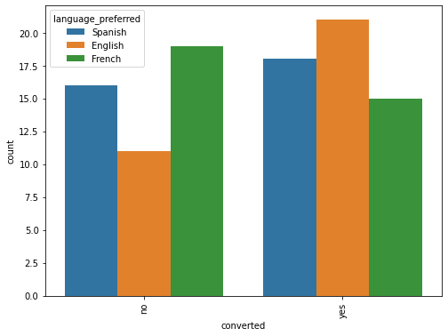

```python
plt.figure(figsize=(8,6))
sns.countplot(data= df, x= 'converted', hue= 'language_preferred');
plt.xticks(rotation= 90);
```

Insights:

There is some variance between conversion and preferred language. More exploring may be necessary to understand if there is clear correlation.

# 1. Do the users spend more time on the new landing page than the existing landing page?

### Perform Visual Analysis

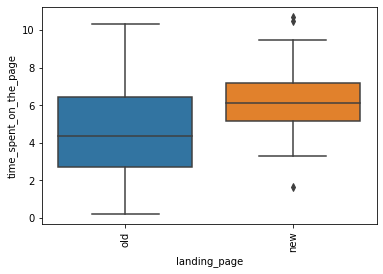

```python
#Looking at comparison with boxplot
sns.boxplot(data= df, x= 'landing_page', y='time_spent_on_the_page');
plt.xticks(rotation= 90);
```

### Step 1: Define the null and alternate hypotheses

Let $\mu$ be the mean time spent on the landing page. With $\mu$1 being the Avg for the existing page and $\mu$2 being the Avg for the new page.

$H_0$: $\mu$1 = $\mu$2

$H_a$: $\mu$1 < $\mu$2

### Step 2: Select Appropriate test

Two independent sample t-test

Assumptions:

Continuous Data - Yes, time spent is continuous.

Normally distributed population and Sample size < 30 - Yes, the population is normal and the sample size is 50.

Observations are from a simple random sample - Yes, we are informed that the collection is a random sample.

Population standard deviation is unknown

### Step 3: Decide the significance level

We are instructed to use a significance level of 5%.

### Step 4: Collect and prepare data

```python
df.head()
```

|  | user_id | group | landing_page | time_spent_on_the_page | converted | language_preferred |
| --- | --- | --- | --- | --- | --- | --- |
| 0 | 546592 | control | old | 3.48 | no | Spanish |
| 1 | 546468 | treatment | new | 7.13 | yes | English |
| 2 | 546462 | treatment | new | 4.40 | no | Spanish |
| 3 | 546567 | control | old | 3.02 | no | French |
| 4 | 546459 | treatment | new | 4.75 | yes | Spanish |

```python
#Finding means of time per old and new page
df.groupby(['landing_page'])['time_spent_on_the_page'].mean()
```

```
landing_page
new    6.2232
old    4.5324
Name: time_spent_on_the_page, dtype: float64
```

```python
df1= df[df['landing_page'] == 'old']
```

```python
df2 = df[df['landing_page'] == 'new']
```

### Step 5: Calculate the p-value

```python
from scipy.stats import ttest_ind

# find the p-value
test_stat, p_value = ttest_ind(df1['time_spent_on_the_page'], df2['time_spent_on_the_page'], equal_var = False, alternative = 'less')
print('The p-value is ', p_value)
```

```
The p-value is  0.0001392381225166549
```

### Step 6: Compare the p-value with $\alpha$

A p-value (~0.0001) is very small and is less than the level of significance of 0.05. Meaning that we can reject the null hypothesis.

### Step 7: Draw inference

As the p-value(~0.0001) is much smaller than the level of significance, we can reject the null hypothesis. We do have enough significance to conclude that there is a difference between time spent on the new page versus the old page.

**A similar approach can be followed to answer the other questions.**

# 2. Is the conversion rate (the proportion of users who visit the landing page and get converted) for the new page greater than the conversion rate for the old page?

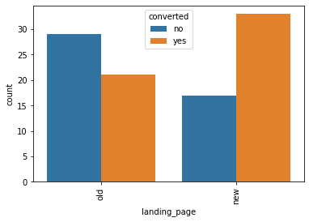

```python
#Visual anlysis
sns.countplot(data= df, x= 'landing_page', hue= 'converted');
plt.xticks(rotation= 90);
```

Visually there may be a significance for conversion between the old and new page.

Let p be the conversion rate for landing page. With p1 being the proportion for the existing page and p2 being the proprtion for the new page. With an alpha value of 5%.

$H_0$: p1 = p2

$H_a$: p1 $\neq$ p2

Two proprtion Z-test

Assumptions:

Binomially distributed populations - Yes, true or false in conversion.

Random Sampling - Yes, we are told samples are randomly selected.

Can be approximated to normal distribution - Let's test below

np$_1$ = 50$\cdot$ $\frac{21}{50}$ = 21 $\geq$ 10

n(1-p$_1$) = 50 $\cdot$ $\frac{50 - 21}{50}$ = 29 $\geq$ 10

np$_2$ = 50$\cdot$ $\frac{33}{50}$ = 33 $\geq$ 10

n(1-p$_2$) = 50 $\cdot$ $\frac{50 - 33}{50}$ = 17 $\geq$ 10

Yes, np and n(1-p) are greater than or equal to 10.

```python
df1['converted'].value_counts()
```

```
no     29
yes    21
Name: converted, dtype: int64
```

```python
df2['converted'].value_counts()
```

```
yes    33
no     17
Name: converted, dtype: int64
```

```python
#setting arrays for proportions z test
count = np.array([21, 33])

nobs = np.array([50, 50])
```

```python
from statsmodels.stats.proportion import proportions_ztest

test_stat, p_value = proportions_ztest(count, nobs)
print('The p-value is ' + str(p_value))
```

```
The p-value is 0.016052616408112556
```

The p-value (~0.02) is less than the level of significance, we can reject the null hypothesis. Meaning that we have enough significance to conclude that there is a difference in conversion rate for landing page.

# 3. Is the conversion and preferred language are independent or related?

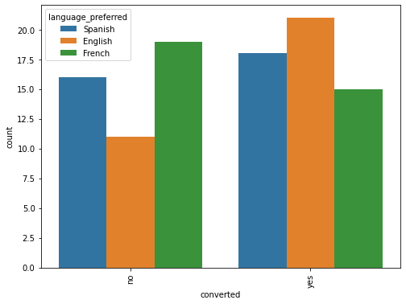

```python
#Visual Analysis
plt.figure(figsize=(8,6))
sns.countplot(data= df, x= 'converted', hue= 'language_preferred');
plt.xticks(rotation= 90);
```

$H_0:$ Conversion is independent of preferred language

$H_a:$ Conversion depends on preferred language

Chi-Square Test of Independence

Significance of level 5%

Assumptions:

Categorical variables - Yes.

Expected value of the number of sample observations in each level of the variable is at least 5 - Yes.

Random sampling from the population - Yes, we are informed that the collected sample is a random sample.

```python
df_table = pd.crosstab(df['converted'], df['language_preferred'], margins=False, normalize=False)
df_table
```

| language_preferred converted | English | French | Spanish |
| --- | --- | --- | --- |
| no | 11 | 19 | 16 |
| yes | 21 | 15 | 18 |

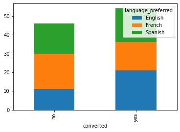

```python
pd.crosstab(df['converted'], df['language_preferred']).plot(kind='bar', stacked=True)
```

```python
#Calculate p-value
from scipy.stats import chi2_contingency

chi, p_value, dof, expected = chi2_contingency(df_table)

print('The p-value is', p_value)
```

```
The p-value is 0.21298887487543447
```

# 4. Is the time spent on the new page same for the different language users?

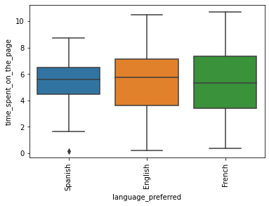

```python
#Visual Analysis
sns.boxplot(data= df, x= 'language_preferred', y='time_spent_on_the_page');
plt.xticks(rotation= 90);
```

```python
df['language_preferred'].value_counts()
```

```
Spanish    34
French     34
English    32
Name: language_preferred, dtype: int64
```

```python
df.groupby('language_preferred')['time_spent_on_the_page'].mean()
```

```
language_preferred
English    5.559062
French     5.253235
Spanish    5.331765
Name: time_spent_on_the_page, dtype: float64
```

Define null and alternative hypothesis

Let $\mu_1, \mu_2, \mu_3$ be the means of time spent on the page for different language users (Spanish, English, French).

$H_0: \mu_1 = \mu_2 = \mu_3$

$H_a: $ At least one level is different from the rest.

One way ANOVA F-test

Assumptions:

The populations are normally distributed - We will test with Shapiro-Wilk's Test

Sample are independent simple random sample - Yes, we are informed samples collected are simple random samples.

Populations variances are equal - We will test with Levene's Test

Shapiro-Wilk's test for normality

H$_0$ : Time spent on the page follows a normal distribution

H$_a$ : Time spent on the page does not follow a normal distribution

```python
#Shapiro-Wilk's test for normality
from scipy import stats

w, p_value = stats.shapiro(df['time_spent_on_the_page'])
print('The p-value is', p_value)
```

```
The p-value is 0.5643684267997742
```

The p-value (~0.56) is large, hence we fail to reject the null hypothesis. Meaning time spent on the page follows a normal distribution.

Levene's Test for equality of variances

H$_0$ : All the population variances are equal

H$_a$ : At least one population variance is not equal

```python
#Levene's Test
from scipy.stats import levene

statistic, p_value = levene(df['time_spent_on_the_page'][df['language_preferred']== 'Spanish'],
                            df['time_spent_on_the_page'][df['language_preferred']== 'English'],
                            df['time_spent_on_the_page'][df['language_preferred']== 'French'])

print('The p-value is', p_value)
```

```
The p-value is 0.06515086840327314
```

The p-value (~0.07) is greater than the level of significance (0.05), therefore we fail to reject the null hypothesis. Meaning that we can conclude that the population variances are equal.

Now knowing the assumptions are supported, we can carry on with the one-way ANOVA F-test. Let's revisit the hypotheses below:

Let $\mu_1, \mu_2, \mu_3$ be the means of time spent on the page for different language users (Spanish, English, French). With a level of significance of 5%.

$H_0: \mu_1 = \mu_2 = \mu_3$

$H_a: $ At least one level is different from the rest.

```python
#one-way ANOVA test
from scipy.stats import f_oneway

test_stat, p_value = f_oneway(df.loc[df['language_preferred']== 'Spanish', 'time_spent_on_the_page'],
                              df.loc[df['language_preferred']== 'English', 'time_spent_on_the_page'],
                              df.loc[df['language_preferred']== 'French', 'time_spent_on_the_page'])

print('The p-value is', p_value)
```

```
The p-value is 0.8665610536012648
```

# Conclusion and Business Recommendations

Summary:

E-news Express has developed a new landing page and has collected data to compare the effectiveness of the new page compared to the existing page in an effort to increase subscriptions. The design team has posed questions about the collected data which will be answered below:

> Do the users spend more time on the new landing page than on the existing landing page?

From the sample, we can conclude that users do spend more time on the new landing page compared to the existing page.

> Is the conversion rate (the proportion of users who visit the landing page and get converted) for the new page greater than the conversion rate for the old page?

From the sample, we can conclude that there is a significant difference in conversion rate from new and old landing page. We can determine from the sample that the new landing page results in a higher conversion rate.

> Does the converted status depend on the preferred language?

From the sample, we can conclude that conversion and preferred language are independent.

> Is the time spent on the new page the same for the different language users?

From the sample, we can conclude that different language users spend the same amount of time on the page.

Conclusion:

From the analysis conducted, we can recommend the action of replacing the existing page with the new page, as there is more engagement and a higher conversion rate. There is no significant difference in user behavior when comparing different language preferences. Going forward, it may be worthwhile to continue exploration into the page to further gauge user behavior. Actions may be completed to scrutinize if specific featured stories or delivery methods increase engagement. Also research may be taken to focus on best practices to persuade users to subscribe to E-news Express.

```python
#! jupyter nbconvert --to html /content/drive/MyDrive/
```